# About the Hybrid OA Dashboard

updated 2019-02-05

## Summary

[This open source dashboard](https://subugoe.shinyapps.io/hybridoa/) presents the uptake of hybrid open access for 3,988 different journals from 52 publishers between 2013 - 2019. During this six years period, 150,864 articles were made openly available immediately in these subscription-based journals, representing 2.7% of the total article volume studied.

Hybrid open access journals are included when they meet the following two conditions:

1. academic institutions sponsored the publication fee or enabled open access publication through an offsetting agreement according to the [Open APC initiative](https://github.com/openapc/openapc-de),
2. publishers shared licensing information about fulltext accessibility and re-use rights with [Crossref](https://www.crossref.org/).

By bringing together openly available datasets about hybrid open access into one easy-to-use tool, this dashboard demonstrates how existing pieces of an evolving and freely available data infrastructure for monitoring scholarly publishing can be re-used to gain a better understanding of hybrid open access publishing. It, thus, contributes to recent calls from the [Open Access 2020 Initiative](https://oa2020.org/) and [Open Knowledge](https://blog.okfn.org/2017/10/24/understanding-the-costs-of-scholarly-publishing-why-we-need-a-public-data-infrastructure-of-publishing-costs/) aiming at a data-driven debate about how to transition subscription-based journal publishing to open access.

This document gives information about the study design, as well as how to use the dashboard. Because this open source dashboard was built around already existing infrastructure services for scholarly publishing, discussion will also include guidance about how publishers can properly report hybrid open access journal articles to Crossref in accordance with evolving standards like the [ESAC guidelines](http://esac-initiative.org/its-the-workflows-stupid-what-is-required-to-make-offsetting-work-for-the-open-access-transition/).

## Data and methods

Many publishers offer hybrid open access journals (Suber 2012). However, because of non-standardised reporting practices, it is hard to keep track of how many articles were provided immediately in open access by these journals, and to what extent these figures relate to the overall article volume published (Björk 2017). In particular, it is challenging to determine subscription-based journals that already did publish open access articles, as well as to obtain proper licensing information about access and re-use rights (Laakso and Björk 2016; Piwowar et al. 2017).

To reflect the challenge of finding hybrid open access journals with published open access articles, we started with a sample of hybrid open access journals from the [Open APC initiative](https://github.com/OpenAPC/openapc-de/). This open data initiative crowd-source information about spending on open access journal articles from various international research organisations. [Its openly available dataset](https://github.com/OpenAPC/openapc-de/blob/master/data/apc_de.csv) differentiates expenditure for articles published in hybrid and in fully open access journals. It also has a dedicated dataset containing information about articles, which were made openly available as part of [offsetting deals](https://github.com/OpenAPC/openapc-de/tree/master/data/offsetting), central agreements between publishers and large research organisations or consortia aiming at transitioning subscription-based licensing to open access business models. Using data from the [Open APC initiative](https://github.com/OpenAPC/openapc-de/), thus, ensured that only hybrid open access journals with at least one centrally funded open access article were examined.

After obtaining data about hybrid open access journals from the Open APC initiative, [Crossref’s REST API](https://github.com/CrossRef/rest-api-doc) was queried to discover open access articles published in these journals, as well as to retrieve yearly article volumes for the period 2013 - 2019. Using the rcrossref client, developed and maintained by the [rOpenSci initiative](https://ropensci.org/), the first API call retrieved all licenses URLs available per ISSN. To control developments of the publishing market resulting in name changes of publishers or journal titles over time, only the most frequent facet field name was used. After matching and normalizing licensing URLs indicating open access articles with the help of the [dissem.in / oaDOI access indicator list](https://github.com/dissemin/dissemin/blob/0aa00972eb13a6a59e1bc04b303cdcab9189406a/backend/crossref.py#L89), a second API call checked licensing metadata to exclude delayed open access articles by using the [Crossref’s REST API filters](https://github.com/CrossRef/rest-api-doc#filter-names) `license.url` and `license.delay` for the every single year in period of 2013 - 2019. Because journal business models can change from hybrid to fully open access over time, the [Directory of Open Access Journals (DOAJ)](https://doaj.org/), a curated list of fully open access journals, was finally checked to exclude these journals by ISSNs. To improve this matching, DOAJ data was enriched with further ISSN variants from Rimmert et al. (2017).

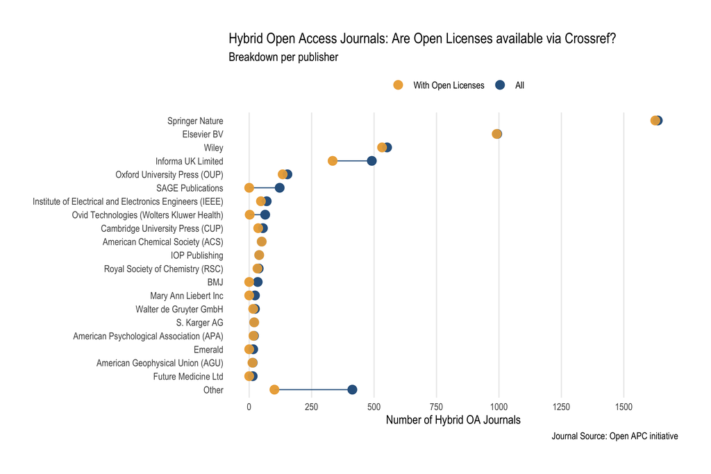

*Figure: Overview of Crossref licensing coverage per publisher. Yellow dots represent the number of hybrid open access journals disclosed by the Open APC initiative with licensing metadata, blue dots the overall number of hybrid open access journals in our sample.*

Data were gathered on 2019-02-04. Methods were implemented in R and were made openly available in the source code repository of this project hosted on [GitHub](https://github.com/subugoe/hybrid_oa_dashboard) together with the compiled datasets. A [Shiny web application](https://shiny.rstudio.com/) was built to present the results using [flexdashboard](http://rmarkdown.rstudio.com/flexdashboard/) package. The app is powered by the graphic packages plotly, [ggplot2](http://ggplot2.tidyverse.org/) and ggalt, as well as [readr](http://readr.tidyverse.org/) for data import. Data analysis made use of [dplyr](http://dplyr.tidyverse.org/).

## Results

Using data from Open APC and Crossref, we found 150,864 open access articles published in 3,988 subscription-based journals from 52 publishers between 2013 - 2019. These articles accounted for about 2.7% of the overall journal article volume investigated.

Results at the publisher and journal level are accessible and browsable through an [interactive dashboard using dynamic graphs](https://subugoe.shinyapps.io/hybridoa/). Launching the app shows up the overall results that can be subsetted by publisher or journal via the select boxes in the left sidebar. Publisher names are decreasingly sorted according to the number of hybrid open access articles published. Corresponding journals are filtered conditionally to the publisher selection and are sorted alphabetically.

[figure not shown]

*Figure 2: Screenshot of the Hybrid OA Dashboard available at https://subugoe.shinyapps.io/hybridoa/*

### Hybrid OA uptake

The upper part of the dashboard allows to explore the annual development of hybrid open access publishing between 2013 - 2019. The first tab shows the relative uptake of hybrid open access, the second tab the absolute number of published hybrid open access articles on a yearly basis. Bar charts are sub-grouped according to the licensing links found via Crossref. Overall results indicate that the number and proportion of hybrid open access journal articles rose between 2013 (4,426 articles, OA share: 0.56 %) and 2017 (36,809 articles, OA share: 3.8 %).

Table 1 presents an additional breakdown by publishers, contrasting the number of journals with the number of articles found. The three publishers Elsevier BV, Springer Nature and Wiley-Blackwell are leading, accounting for the largest proportion of hybrid open access journals (79 %) and open access articles (82 %) found.

| Publisher | Journals (in %) | Article volume (in %) | Hybrid OA article volume | OA proportion per publisher (in %) | Overall OA proportion (in %) |
| --- | --- | --- | --- | --- | --- |
| Elsevier BV | 991 (24.82 %) | 2445292 (43.35 %) | 57629 | 2.36 | 38.20 |
| Springer Nature | 1626 (40.73 %) | 1089158 (19.31 %) | 49650 | 4.56 | 32.91 |
| Wiley | 532 (13.33 %) | 700443 (12.42 %) | 15819 | 2.26 | 10.49 |
| Oxford University Press (OUP) | 134 (3.36 %) | 275727 (4.89 %) | 5023 | 1.82 | 3.33 |
| American Chemical Society (ACS) | 50 (1.25 %) | 274849 (4.87 %) | 4678 | 1.70 | 3.10 |
| Informa UK Limited | 334 (8.37 %) | 185982 (3.3 %) | 1416 | 0.76 | 0.94 |
| American Physical Society (APS) | 9 (0.23 %) | 109046 (1.93 %) | 4595 | 4.21 | 3.05 |
| Royal Society of Chemistry (RSC) | 33 (0.83 %) | 98625 (1.75 %) | 306 | 0.31 | 0.20 |
| Institute of Electrical and Electronics Engineers (IEEE) | 47 (1.18 %) | 91800 (1.63 %) | 138 | 0.15 | 0.09 |
| IOP Publishing | 40 (1 %) | 84549 (1.5 %) | 4493 | 5.31 | 2.98 |

[output cut: 42 more lines]

*Table 1: Hybrid open access journal and article breakdown by publisher.*

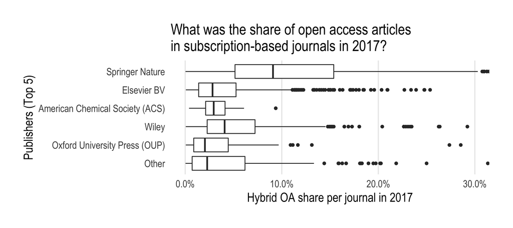

*Figure 3: Box plot characterizing spread and differences of the share of open access articles provided by subscription-based journal per publisher in 2017 using five summary statistics (the median, the 25th and 75th percentiles, and 1.5 times the inter-quartile range between the first and third quartiles), and visualizing all outlying points individually.*

### Institutional support

In addition to bibliographic metadata, institutional support either for publication fees or as part of central agreements between research organisations and publishers (offsetting) was also studied. The lower left chart in the dashboard compares the number of articles found via Open APC and Crossref for the selection. The lower right chart indicates from which countries the institutional support originated from.

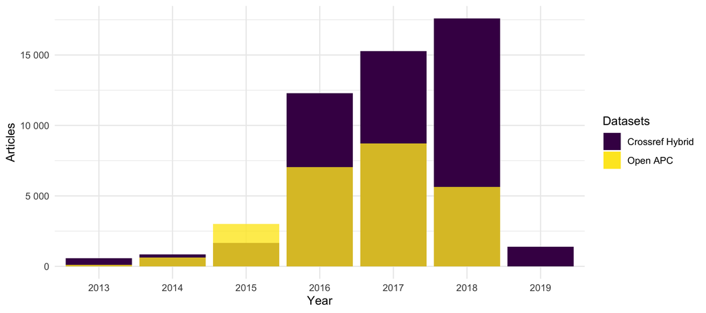

## Discussion and conclusion

This dashboard demonstrates the uptake of hybrid open access publishing for a sample of subscription-based journals where institutional support facilitated the open access publication of individual articles, and where licensing metadata about the open access status were made available via Crossref. In using open data sources and tools to analyse and present these data, this dashboard demonstrates how monitoring of hybrid open access can become more transparent and reproducible.

The presented longitudinal findings are consistent with earlier studies, confirming the growth of hybrid open access publishing. According to Laakso and Björk (2016) hybrid open access publishing increased between 2007 - 2013. The authors identified 13,994 hybrid open access articles published in 2,714 different journals during 2013. Björk (2017) also observed an increase since 2014, presumably because of centralized agreements with large publishers. Notably Springer Nature has started to offer offsetting deals to large research organisations like the Max Planck Society and national consortia since then (Geschuhn and Stone 2017). But also recent funding policies in favor of hybrid open access, notably in the UK, likely influenced the uptake of hybrid open access publishing (Pinfield, Salter, and Bath 2017).

While our findings confirm the uptake of hybrid open access in recent years, related studies observed higher proportions of freely available articles in hybrid open access journals. Studying subscription-based journals with at least one identified hybrid open access article as well, Laakso and Björk (2016) determined an open access share of 3.8 % for the period of 2011–2013. Using Crossref metadata, Piwowar et al. (2017) estimated an even higher proportion according to which 9.4 % of articles published in 2015 were provided as hybrid open access. Our future work will, therefore, focus on evaluation our retrieval strategy in terms of precision and recall in order to better understand these differences.

As institutional support of hybrid open access journals grows, the overall aim of this dashboard is to promote evolving standards and infrastructures for analyzing the transition of subscription-based journal publishing to open access. Crossref provides excellent guidance for publishers to make licensing metadata available via the Crossref APIs: https://support.crossref.org/hc/en-us/articles/214572423-License-metadata-Access-Indicators-. For being best represented in this dashboard, publishers will have to make sure to include license URL element `license_ref` and a `start_date` equal to the date of publication in the licensing metadata, which helps to identify open access journal content as well as to differentiate between immediate and delayed open access. Likewise, research institutions, funders, and libraries can increase transparency about hybrid open access publishing including offsetting deals by reporting funded articles to the Open APC initiative on a regular basis. Both practices comply with [ESAC’s recommendation for article workflows and services for offsetting/ open access transformation agreements](http://esac-initiative.org/its-the-workflows-stupid-what-is-required-to-make-offsettin). As this dashboard demonstrates, following these guidelines will help to extend existing methods and data sources to monitor the transition of subscription-based journal publishing to open access in an open and transparent way.

## Meta

### How to contribute?

Dashboard and analysis have been developed in the open using open tools. There are a number of ways you can help make the this work better:

- If you don’t understand something, please let us know and [submit an issue](https://github.com/subugoe/hybrid_oa_dashboard/issues).
- Feel free to add new features or fix bugs by sending a [pull request](https://github.com/subugoe/hybrid_oa_dashboard/pulls).

Please note that this project is released with a [Contributor Code of Conduct](https://github.com/subugoe/hybrid_oa_dashboard/CONDUCT.md). By participating in this project you agree to abide by its terms.

Author: Najko Jahn (Scholarly Communication Analyst, [SUB Göttingen](https://www.sub.uni-goettingen.de/)), 2017.

The R Markdown file, which includes the underlying source code for this document, is available [here](https://github.com/subugoe/hybrid_oa_dashboard/blob/master/docs/about.Rmd).

This work is licensed under a [Creative Commons Attribution 4.0 International License](http://creativecommons.org/licenses/by/4.0/).

## Bibliography

Björk, Bo-Christer. 2017. “Growth of Hybrid Open Access, 2009–2016.” *PeerJ* 5: e3878. https://doi.org/10.7717/peerj.3878.

Geschuhn, Kai, and Graham Stone. 2017. “It’s the Workflows, Stupid! What Is Required to Make ‘Offsetting’ Work for the Open Access Transition.” *Insights the UKSG Journal* 30 (3): 103–14. https://doi.org/10.1629/uksg.391.

Jahn, Najko, and Marco Tullney. 2016. “A Study of Institutional Spending on Open Access Publication Fees in Germany.” *PeerJ* 4: e2323. https://doi.org/10.7717/peerj.2323.

Laakso, Mikael, and Bo-Christer Björk. 2016. “Hybrid Open Access–a Longitudinal Study.” *Journal of Informetrics* 10 (4): 919–32. https://doi.org/10.1016/j.joi.2016.08.002.

Pinfield, Stephen, Jennifer Salter, and Peter A. Bath. 2017. “A Gold-Centric Implementation of Open Access: Hybrid Journals, the "Total Cost of Publication", and Policy Development in the UK and Beyond.” *Journal of the Association for Information Science and Technology* 68 (9): 2248–63. https://doi.org/10.1002/asi.23742.

Piwowar, Heather, Jason Priem, Vincent Larivière, Juan Pablo Alperin, Lisa Matthias, Bree Norlander, Ashley Farley, Jevin West, and Stefanie Haustein. 2017. “The State of Oa: A Large-Scale Analysis of the Prevalence and Impact of Open Access Articles.” PeerJ Preprints. https://doi.org/10.7287/peerj.preprints.3119v1.

Rimmert, Christine, Andre Bruns, Christopher Lenke, and Niels Christian Taubert. 2017. “ISSN-Matching of Gold OA Journals (ISSN-GOLD-OA) 2.0.” Bielefeld University. https://doi.org/10.4119/unibi/2913654.

Solomon, David J., and Bo-Christer Björk. 2011. “Publication Fees in Open Access Publishing: Sources of Funding and Factors Influencing Choice of Journal.” *Journal of the American Society for Information Science and Technology* 63 (1): 98–107. https://doi.org/10.1002/asi.21660.

Suber, Peter. 2012. *Open Access*. MIT Press. https://mitpress.mit.edu/books/open-access.